# HW1 - Data Analysis

##### 負責助教：陳亮宇 catchingfire80@gmail.com

> 此次作業將讓大家確認自己的環境是否安裝成功，  
> 以及 Numpy / Scikit-Learn / Matplotlib 的基本使用

## 評分標準

- 上課繳交：25%
  - 在當天 16:20 前上傳至 new E3 作業，請將以下打包成 .zip 上傳：
    - 程式原始檔 (.ipynb）
    - 程式 .html 檔
- 程式分數：75%
  - 於一週內完成並上傳至 new E3

#### 注意：最終學期成績將視全班原始成績做調整

## 基本資料 - 5%

#### 學號：109705002

## Packages that Might Be Used

```python
import sklearn
import sklearn.datasets
import numpy as np

import matplotlib.pyplot as plt
%matplotlib inline
```

### 相關連結

- Packages
  - [numpy](http://www.numpy.org/)
  - [pandas](https://pandas.pydata.org/)
  - [re](https://docs.python.org/zh-cn/3/library/re.html)
  - [CountVectorizer](https://scikit-learn.org/stable/modules/generated/sklearn.feature_extraction.text.CountVectorizer.html)
  - [LabelEncoder](https://scikit-learn.org/stable/modules/generated/sklearn.preprocessing.LabelEncoder.html)
  - [difflib](https://docs.python.org/2/library/difflib.html)
  - [train_test_split](https://scikit-learn.org/stable/modules/generated/sklearn.model_selection.train_test_split.html)
  - [DecisionTreeClassifier](https://scikit-learn.org/stable/modules/tree.html)
  - [RandomForestClassifier](https://scikit-learn.org/stable/modules/generated/sklearn.ensemble.RandomForestClassifier.html)
  - [classification_report](https://scikit-learn.org/stable/modules/generated/sklearn.metrics.classification_report.html)
  - [confusion_matrix](https://scikit-learn.org/stable/modules/generated/sklearn.metrics.confusion_matrix.html)
  - [pyplot](https://matplotlib.org/tutorials/introductory/pyplot.html)
  - [pyhotpot](https://reurl.cc/dVyqz8)
- Markdown
  - jupyter 可以支援 markdown 區塊，方便打上文字說明此份 notebook 在做的事情
  - [wiki](https://zh.wikipedia.org/wiki/Markdown)
  - [教學](https://markdown.tw/)

## Load Data

#### 請使用 `scikit-learn` 讀取 Wine Dataset - 5% - [Hint](https://scikit-learn.org/stable/modules/generated/sklearn.datasets.load_wine.html)

```python
#sklearn.datasets.load_wine( return_X_y=False, as_frame=False)
wine=sklearn.datasets.load_wine()
wine
```

```
{'data': array([[1.423e+01, 1.710e+00, 2.430e+00, ..., 1.040e+00, 3.920e+00,
         1.065e+03],
        [1.320e+01, 1.780e+00, 2.140e+00, ..., 1.050e+00, 3.400e+00,
         1.050e+03],
        [1.316e+01, 2.360e+00, 2.670e+00, ..., 1.030e+00, 3.170e+00,
         1.185e+03],
        ...,
        [1.327e+01, 4.280e+00, 2.260e+00, ..., 5.900e-01, 1.560e+00,
         8.350e+02],
        [1.317e+01, 2.590e+00, 2.370e+00, ..., 6.000e-01, 1.620e+00,
         8.400e+02],
        [1.413e+01, 4.100e+00, 2.740e+00, ..., 6.100e-01, 1.600e+00,
         5.600e+02]]),
 'target': array([0, 0, 0, 0, 0, 0, 0, 0, 0, 0, 0, 0, 0, 0, 0, 0, 0, 0, 0, 0, 0, 0,
        0, 0, 0, 0, 0, 0, 0, 0, 0, 0, 0, 0, 0, 0, 0, 0, 0, 0, 0, 0, 0, 0,
        0, 0, 0, 0, 0, 0, 0, 0, 0, 0, 0, 0, 0, 0, 0, 1, 1, 1, 1, 1, 1, 1,
        1, 1, 1, 1, 1, 1, 1, 1, 1, 1, 1, 1, 1, 1, 1, 1, 1, 1, 1, 1, 1, 1,
        1, 1, 1, 1, 1, 1, 1, 1, 1, 1, 1, 1, 1, 1, 1, 1, 1, 1, 1, 1, 1, 1,
        1, 1, 1, 1, 1, 1, 1, 1, 1, 1, 1, 1, 1, 1, 1, 1, 1, 1, 1, 1, 2, 2,
        2, 2, 2, 2, 2, 2, 2, 2, 2, 2, 2, 2, 2, 2, 2, 2, 2, 2, 2, 2, 2, 2,
        2, 2, 2, 2, 2, 2, 2, 2, 2, 2, 2, 2, 2, 2, 2, 2, 2, 2, 2, 2, 2, 2,
        2, 2]),
 'frame': None,
 'target_names': array(['class_0', 'class_1', 'class_2'], dtype='<U7'),
 'DESCR': '.. _wine_dataset:\n\nWine recognition dataset\n------------------------\n\n**Data Set Characteristics:**\n\n    :Number of Instances: 178 (50 in each of three classes)\n    :Number of Attributes: 13 numeric, predictive attributes and the class\n    :Attribute Information:\n \t\t- Alcohol\…
 'feature_names': ['alcohol',
  'malic_acid',
  'ash',
  'alcalinity_of_ash',
  'magnesium',
  'total_phenols',
  'flavanoids',
  'nonflavanoid_phenols',
  'proanthocyanins',
  'color_intensity',
  'hue',
  'od280/od315_of_diluted_wines',
  'proline']}
```

## 問題

請簡述以下問題，將 ans 取代為你的答案 - 5%

1. 請問以上 wine 的 target 有幾種分類？每種分類又分別有多少筆資料?
   - 3種，0有59筆， 1有71筆 ，2有48筆

> `wine dataset` 為一 classification（分類）問題，  
> 在一個經典的 classfication 問題中，一筆資料（又稱一 data instance）將包含以下部分：
> - feature （或叫 attribute ）部分
>   - 此筆資料的各項屬性
> - target（或叫 label）部分
>   - 此筆資料的分類

## 分析

#### 印出 `wine` 的 `data` 部分 - 5%

```python
wine['data']
```

```
array([[1.423e+01, 1.710e+00, 2.430e+00, ..., 1.040e+00, 3.920e+00,
        1.065e+03],
       [1.320e+01, 1.780e+00, 2.140e+00, ..., 1.050e+00, 3.400e+00,
        1.050e+03],
       [1.316e+01, 2.360e+00, 2.670e+00, ..., 1.030e+00, 3.170e+00,
        1.185e+03],
       ...,
       [1.327e+01, 4.280e+00, 2.260e+00, ..., 5.900e-01, 1.560e+00,
        8.350e+02],
       [1.317e+01, 2.590e+00, 2.370e+00, ..., 6.000e-01, 1.620e+00,
        8.400e+02],
       [1.413e+01, 4.100e+00, 2.740e+00, ..., 6.100e-01, 1.600e+00,
        5.600e+02]])
```

#### 印出 `wine` 的 `data` 部分的 **shape** - 5% - [hint](https://docs.scipy.org/doc/numpy/reference/generated/numpy.ndarray.shape.html)

```python
wine['data'].shape
```

```
(178, 13)
```

#### 可以看出 `wine dataset` 具有 178 筆資料，而每筆資料有 13 個 features

#### 印出 `wine` 的 feature - 5%

```python
wine['feature_names']
```

```
['alcohol',
 'malic_acid',
 'ash',
 'alcalinity_of_ash',
 'magnesium',
 'total_phenols',
 'flavanoids',
 'nonflavanoid_phenols',
 'proanthocyanins',
 'color_intensity',
 'hue',
 'od280/od315_of_diluted_wines',
 'proline']
```

#### 印出 `wine` 的 target (label) - 5%

```python
wine['target']
```

```
array([0, 0, 0, 0, 0, 0, 0, 0, 0, 0, 0, 0, 0, 0, 0, 0, 0, 0, 0, 0, 0, 0,
       0, 0, 0, 0, 0, 0, 0, 0, 0, 0, 0, 0, 0, 0, 0, 0, 0, 0, 0, 0, 0, 0,
       0, 0, 0, 0, 0, 0, 0, 0, 0, 0, 0, 0, 0, 0, 0, 1, 1, 1, 1, 1, 1, 1,
       1, 1, 1, 1, 1, 1, 1, 1, 1, 1, 1, 1, 1, 1, 1, 1, 1, 1, 1, 1, 1, 1,
       1, 1, 1, 1, 1, 1, 1, 1, 1, 1, 1, 1, 1, 1, 1, 1, 1, 1, 1, 1, 1, 1,
       1, 1, 1, 1, 1, 1, 1, 1, 1, 1, 1, 1, 1, 1, 1, 1, 1, 1, 1, 1, 2, 2,
       2, 2, 2, 2, 2, 2, 2, 2, 2, 2, 2, 2, 2, 2, 2, 2, 2, 2, 2, 2, 2, 2,
       2, 2, 2, 2, 2, 2, 2, 2, 2, 2, 2, 2, 2, 2, 2, 2, 2, 2, 2, 2, 2, 2,
       2, 2])
```

#### 印出 `wine` 的第 39, 48, 99, 170 個 data instances （並包含其 target / label） - 10% - [Hint](https://docs.scipy.org/doc/numpy/reference/arrays.indexing.html)

Note: 格式可以稍微不同

```python
indices = [39, 48, 99, 170]
index=4
for i in range(index):
    print(indices[i],"th:",wine.data[indices[i]],wine.target[indices[i]])
```

```
39 th: [1.422e+01 3.990e+00 2.510e+00 1.320e+01 1.280e+02 3.000e+00 3.040e+00
 2.000e-01 2.080e+00 5.100e+00 8.900e-01 3.530e+00 7.600e+02] 0
48 th: [1.41e+01 2.02e+00 2.40e+00 1.88e+01 1.03e+02 2.75e+00 2.92e+00 3.20e-01
 2.38e+00 6.20e+00 1.07e+00 2.75e+00 1.06e+03] 0
99 th: [ 12.29   3.17   2.21  18.    88.     2.85   2.99   0.45   2.81   2.3
   1.42   2.83 406.  ] 1
170 th: [1.22e+01 3.03e+00 2.32e+00 1.90e+01 9.60e+01 1.25e+00 4.90e-01 4.00e-01
 7.30e-01 5.50e+00 6.60e-01 1.83e+00 5.10e+02] 2
```

```python
for i in range(7):
    print(wine.feature_names[i],'\n')
    for j in range(13):
        print(np.max(wine.data[i][j]))
```

```
alcohol

14.23
1.71
2.43
15.6
127.0
2.8
3.06
0.28
2.29
5.64
1.04
3.92
1065.0
malic_acid

13.2
1.78
2.14
11.2
100.0
2.65
2.76
0.26
1.28
4.38
1.05
3.4
1050.0
ash

13.16
2.36
2.67
18.6
101.0
2.8
3.24
0.3
```

[output cut: 50 more lines]

```
flavanoids

14.39
1.87
2.45
14.6
96.0
2.5
2.52
0.3
1.98
5.25
1.02
3.58
1290.0
```

## Visualization

#### 對 `alcohol`, `malic_acid`, `ash` 三個 feature，各自繪製一 scatter 圖 - 20%

- title 為其 feature 名字
- X 軸為其 target，並需對應 class_0 - class_2
- Y 軸為該 feature 在對應的 target 下的分佈
- 點需依照 target 上色，三個 target 需顏色不同

Hints:

- [pyplot.title](https://matplotlib.org/3.1.1/api/_as_gen/matplotlib.pyplot.title.html)
- [pyplot.scatter](https://matplotlib.org/3.1.1/api/_as_gen/matplotlib.pyplot.scatter.html)
- [pyplot.xticks](https://matplotlib.org/3.1.1/api/_as_gen/matplotlib.pyplot.xticks.html)

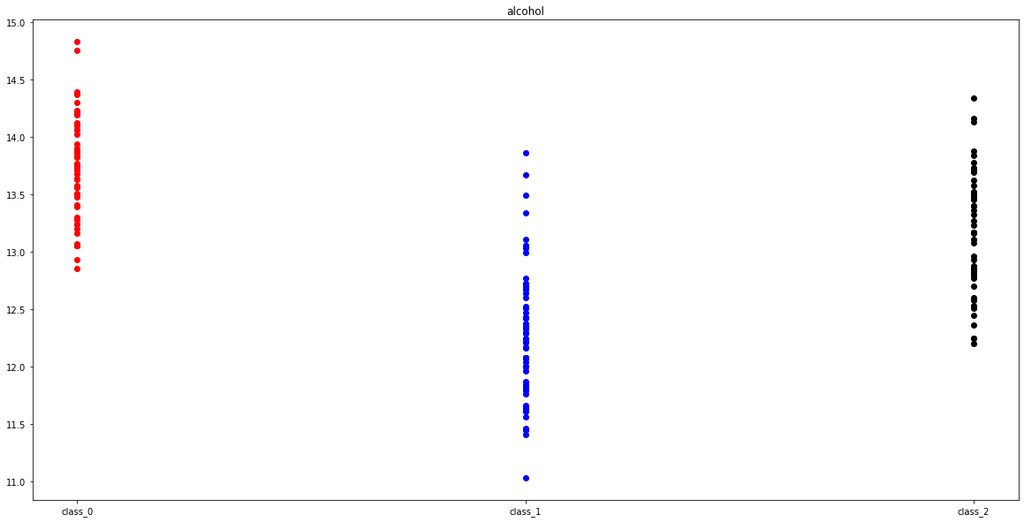

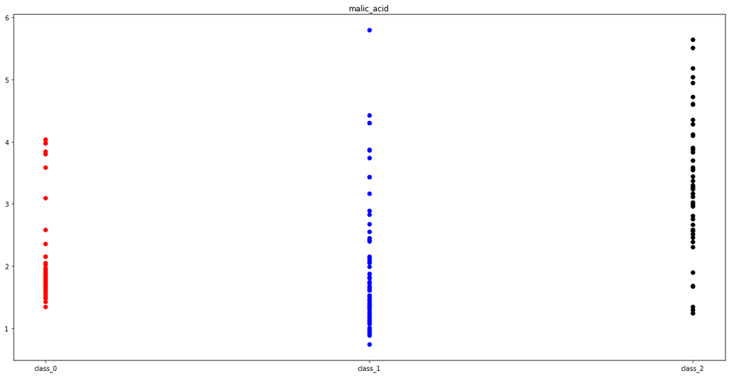

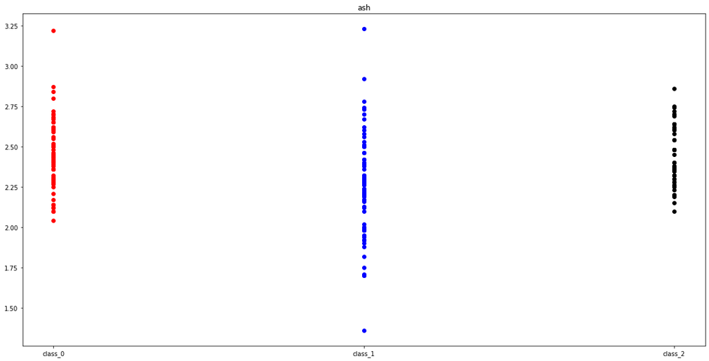

```python
for i in range(3):
    plt.figure(figsize=(20, 10)) # 讓你的圖看起來大大的
    plt.title(wine.feature_names[i], fontdict=None, loc='center', pad=None)
    plt.xticks(np.arange(3), wine.target_names)
    for j in range(178):
        if(wine.target[j]==0):
            cl='red'
        elif(wine.target[j]==1):
            cl='blue'
        else:
            cl='black'
        plt.scatter(wine.target[j],np.split(wine.data.T,13,axis=0)[i][0][j],c=cl)
    plt.show() # 畫圖囉
```

#### 挑選兩個 feature 並繪製一張 scatter 圖 - 20%

- 點須依照 target 上色，各 target 顏色不相同
- X 及 Y 座標需以該 feature 命名

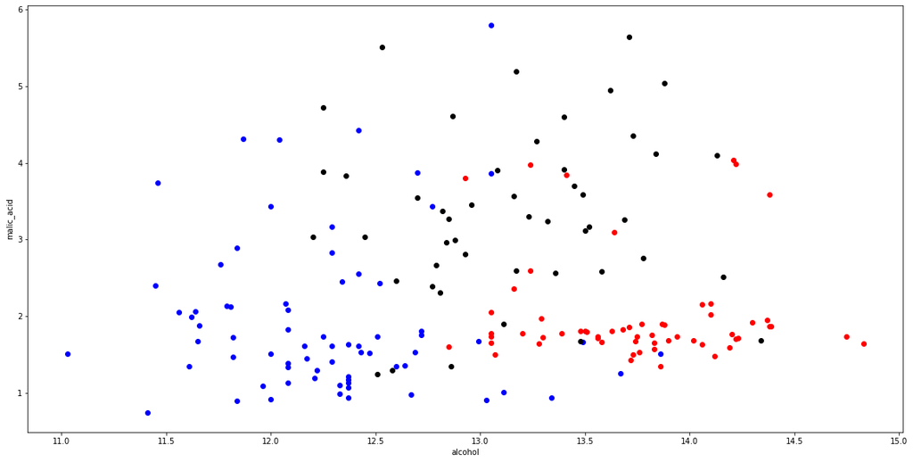

```python
plt.figure(figsize=(20, 10)) # 讓你的圖看起來大大的
plt.xlabel('alcohol')
plt.ylabel('malic_acid')
for i in range(178):
    if(wine.target[i]==0):
        plt.scatter(wine.data[i][0],wine.data[i][1],c='red') #s可以改變大小 plt.scatter(wine.data[x][6],wine.data[x][7],c='b',s=100)
    elif(wine.target[i]==1):
        plt.scatter(wine.data[i][0],wine.data[i][1],c='blue') #alpha可以改變透明度  plt.scatter(wine.data[x][6],wine.data[x][7],c='b',alpha=0.2)
    else:
        plt.scatter(wine.data[i][0],wine.data[i][1],c='black')
plt.show()
```

#### 簡述為什麼你認為應該要挑選此兩個 feature - 5%

- 我想知道這兩個feature之間有沒有什麼關聯，藉此來實驗一下

## 有沒有什麼想對助教說的話?

機器學習好好玩 助教也是帥哥VT廚

[figure not shown]